# Matthew Bierman, Homework 3

### Purpose:

The purpose of this script is to find a good predictor for cell malignancy, since Cell.size and Cell.shape doesn’t work well as predictors.

## 1.

a.) There are 699 instances.

b.) The target column is ‘Class’.

c.) There are 9 predictors and they are of the factor and ordinal factor data types.

d.) 34.48% of observations are malignant.

```r
library(mlbench)            # Loading library mlbench
data(BreastCancer)          # Load BreastCancer dataset into memory
str(BreastCancer)           # Overview of data
```

```
## 'data.frame':    699 obs. of  11 variables:
##  $ Id             : chr  "1000025" "1002945" "1015425" "1016277" ...
##  $ Cl.thickness   : Ord.factor w/ 10 levels "1"<"2"<"3"<"4"<..: 5 5 3 6 4 8 1 2 2 4 ...
##  $ Cell.size      : Ord.factor w/ 10 levels "1"<"2"<"3"<"4"<..: 1 4 1 8 1 10 1 1 1 2 ...
##  $ Cell.shape     : Ord.factor w/ 10 levels "1"<"2"<"3"<"4"<..: 1 4 1 8 1 10 1 2 1 1 ...
##  $ Marg.adhesion  : Ord.factor w/ 10 levels "1"<"2"<"3"<"4"<..: 1 5 1 1 3 8 1 1 1 1 ...
##  $ Epith.c.size   : Ord.factor w/ 10 levels "1"<"2"<"3"<"4"<..: 2 7 2 3 2 7 2 2 2 2 ...
##  $ Bare.nuclei    : Factor w/ 10 levels "1","2","3","4",..: 1 10 2 4 1 10 10 1 1 1 ...
##  $ Bl.cromatin    : Factor w/ 10 levels "1","2","3","4",..: 3 3 3 3 3 9 3 3 1 2 ...
##  $ Normal.nucleoli: Factor w/ 10 levels "1","2","3","4",..: 1 2 1 7 1 7 1 1 1 1 ...
##  $ Mitoses        : Factor w/ 9 levels "1","2","3","4",..: 1 1 1 1 1 1 1 1 5 1 ...
##  $ Class          : Factor w/ 2 levels "benign","malignant": 1 1 1 1 1 2 1 1 1 1 ...
```

```r
head(BreastCancer)          # First few rows of dataset
```

```
##        Id Cl.thickness Cell.size Cell.shape Marg.adhesion Epith.c.size
## 1 1000025            5         1          1             1            2
## 2 1002945            5         4          4             5            7
## 3 1015425            3         1          1             1            2
## 4 1016277            6         8          8             1            3
## 5 1017023            4         1          1             3            2
## 6 1017122            8        10         10             8            7
##   Bare.nuclei Bl.cromatin Normal.nucleoli Mitoses     Class
## 1           1           3               1       1    benign
## 2          10           3               2       1    benign
## 3           2           3               1       1    benign
## 4           4           3               7       1    benign
## 5           1           3               1       1    benign
## 6          10           9               7       1 malignant
```

```r
summary(BreastCancer$Class) # Distribution summary of Class column in dataset
```

```
##    benign malignant
##       458       241
```

```r
paste("Benign:", sum(BreastCancer$Class == "benign") / dim(BreastCancer)[1])    # Percentage of benign observations
```

```
## [1] "Benign: 0.655221745350501"
```

```r
paste("Malignant:", sum(BreastCancer$Class == "malignant") / dim(BreastCancer)[1])    # Percentage of malignant observations
```

```
## [1] "Malignant: 0.344778254649499"
```

## 2.

The warning means the data could be linearly separable. This could be fixed by measuring size and/or shape with integers or doubles instead of factors.

```r
glm0 <- glm(Class~Cell.size+Cell.shape, data = BreastCancer, family = binomial)   # Generalized linear model using Cell.size and Cell.shape to predict Class
```

```
## Warning: glm.fit: fitted probabilities numerically 0 or 1 occurred
```

```r
summary(glm0)
```

```
##
## Call:
## glm(formula = Class ~ Cell.size + Cell.shape, family = binomial,
##     data = BreastCancer)
##
## Deviance Residuals:
##     Min       1Q   Median       3Q      Max
## -2.6380  -0.0844  -0.0844   0.0000   3.3583
##
## Coefficients:
##                Estimate Std. Error z value Pr(>|z|)
## (Intercept)     7.77977  757.06736   0.010    0.992
## Cell.size.L    10.45177  950.68969   0.011    0.991
## Cell.size.Q     0.04064 1479.65505   0.000    1.000
## Cell.size.C    10.70546  948.84001   0.011    0.991
## Cell.size^4    12.06582 1241.92612   0.010    0.992
## Cell.size^5     0.74199  792.70275   0.001    0.999
## Cell.size^6    -3.08210 1011.79270  -0.003    0.998
## Cell.size^7     7.47104 1044.50458   0.007    0.994
## Cell.size^8     5.60143  830.93455   0.007    0.995
## Cell.size^9   -10.22144 1812.16583  -0.006    0.995
## Cell.shape.L   18.15803 2619.03273   0.007    0.994
## Cell.shape.Q    9.14381 1500.17066   0.006    0.995
## Cell.shape.C    5.50082 1302.51294   0.004    0.997
## Cell.shape^4   -2.23752 2679.86504  -0.001    0.999
## Cell.shape^5   -5.76978 3193.32617  -0.002    0.999
## Cell.shape^6   -5.58415 2713.54604  -0.002    0.998
## Cell.shape^7   -3.94569 1740.80777  -0.002    0.998
## Cell.shape^8   -1.82009  827.39680  -0.002    0.998
## Cell.shape^9   -0.77209  257.90964  -0.003    0.998
##
## (Dispersion parameter for binomial family taken to be 1)
##
##     Null deviance: 900.53  on 698  degrees of freedom
## Residual deviance: 198.66  on 680  degrees of freedom
## AIC: 236.66
##
## Number of Fisher Scoring iterations: 19
```

## 3.

Yes, this is a good idea, because the glm0 model only resulted in 0 or 1 and logistic regression wouldn’t work well on 10 different factors for both Cell.size and Cell.shape.

```r
BreastCancer$Cell.small <- 0                                    # Create Cell.small column with default values 0
BreastCancer$Cell.small[BreastCancer$Cell.size == 1] <- 1       # Change value in Cell.small to 1 if Cell.size is 1
BreastCancer$Cell.small <- factor(BreastCancer$Cell.small)      # Convert Cell.small to factor instead of int

BreastCancer$Cell.regular <- 0                                  # Create Cell.regular column with default values 0
BreastCancer$Cell.regular[BreastCancer$Cell.shape == 1] <- 1    # Change value in Cell.regular to 1 if Cell.size is 1
BreastCancer$Cell.regular <- factor(BreastCancer$Cell.regular)  # Convert Cell.regular to factor instead of int

summary(BreastCancer$Cell.size)                                 # Distribution summary for Cell.size column
```

```
##   1   2   3   4   5   6   7   8   9  10
## 384  45  52  40  30  27  19  29   6  67
```

```r
summary(BreastCancer$Cell.shape)                                # Distribution summary for Cell.shape column
```

```
##   1   2   3   4   5   6   7   8   9  10
## 353  59  56  44  34  30  30  28   7  58
```

```r
summary(BreastCancer$Cell.small)                                # Distribution summary for Cell.small column
```

```
##   0   1
## 315 384
```

```r
summary(BreastCancer$Cell.regular)                              # Distribution summary for Cell.regular column
```

```
##   0   1
## 346 353
```

## 4.

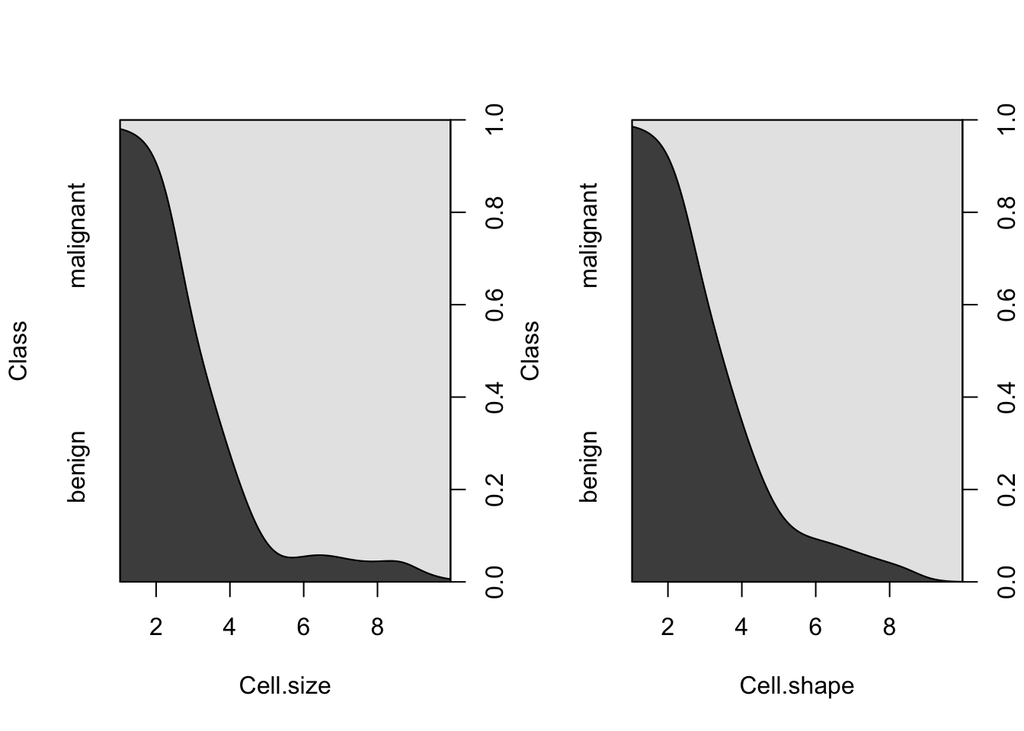

```r
attach(BreastCancer)
par(mfrow = c(1, 2))
cdplot(Class~Cell.size)     # Density plot for Cell.size vs. Class
cdplot(Class~Cell.shape)    # Density plot for Cell.shape vs. Class
```

## 5.

The question says “Create plots (**not cdplots**) with our new columns …” but then contradicts itself by saying “… Now create two **cdplot()** graphs for the new columns …”, so I showed both just to be safe.

```r
attach(BreastCancer)
```

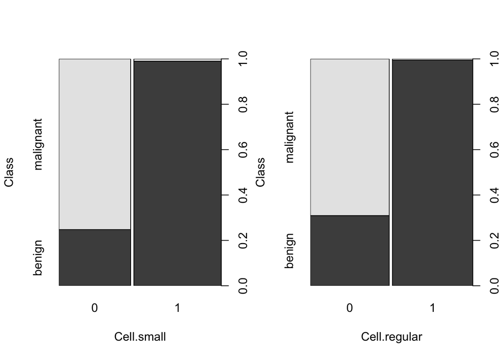

```r
par(mfrow = c(1, 2))
plot(Class~Cell.small)      # Plot for Cell.small vs. Class
plot(Class~Cell.regular)    # Plot for Cell.regular vs. Class
```

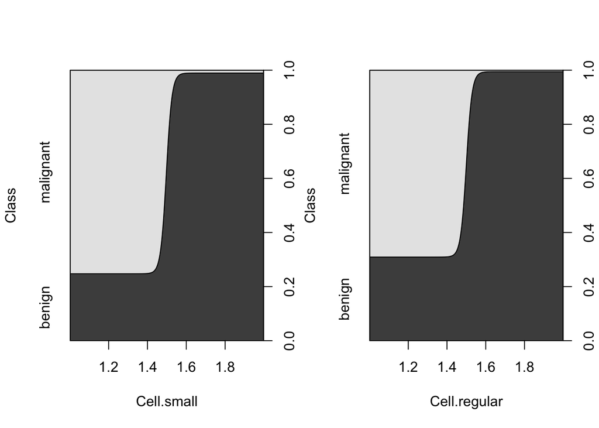

```r
par(mfrow = c(1, 2))
cdplot(Class~Cell.small)    # Density plot for Cell.small vs. Class
cdplot(Class~Cell.regular)  # Density plot for Cell.regular vs. Class
```

```r
paste ("Percentage of small observations that are malignant: ", 100 * sum(Cell.small == 1 & Class == "malignant") / sum(Class == "malignant"), "%", sep = "")
```

```
## [1] "Percentage of small observations that are malignant: 1.6597510373444%"
```

```r
paste ("Percentage of non-small observations that are malignant: ", 100 * sum(Cell.small == 0 & Class == "malignant") / sum(Class == "malignant"), "%", sep = "")
```

```
## [1] "Percentage of non-small observations that are malignant: 98.3402489626556%"
```

```r
paste ("Percentage of regular observations that are malignant: ", 100 * sum(Cell.regular == 1 & Class == "malignant") / sum(Class == "malignant"), "%", sep = "")
```

```
## [1] "Percentage of regular observations that are malignant: 0.829875518672199%"
```

```r
paste ("Percentage of non-regular observations that are malignant: ", 100 * sum(Cell.regular == 0 & Class == "malignant") / sum(Class == "malignant"), "%", sep = "")
```

```
## [1] "Percentage of non-regular observations that are malignant: 99.1701244813278%"
```

## 6.

```r
set.seed(1234)
i <- sample(1:nrow(BreastCancer), nrow(BreastCancer) * 0.80, replace = FALSE)   # take random sample from dataset to divide into train and test
train <- BreastCancer[i,]     # 80% of dataset in train
test <- BreastCancer[-i,]     # 20% of dataset in test
```

## 7.

a.) Cell.small (cell size) and Cell.regular (cell shape) are both very good predictors of breast cancer, as their Type II errors are less than two percent for both predictors (as shown in Question #5) and the p-value is nearly 0 for both predictors.

b.) Both null deviance and residual deviance have high values, while the residual deviance has a value much lower than the null deviance value while being only two degrees of freedom lower.

c.) The AIC score is fairly large, as it is greater than the residual deviance and less than the null deviance.

```r
glm1 <- glm(Class~Cell.small+Cell.regular, data = BreastCancer, family = binomial)  # Generalized linear model using Cell.small and Cell.regular to predict Class
summary(glm1)
```

```
##
## Call:
## glm(formula = Class ~ Cell.small + Cell.regular, family = binomial,
##     data = BreastCancer)
##
## Deviance Residuals:
##     Min       1Q   Median       3Q      Max
## -1.8041  -0.0517  -0.0517   0.6614   3.6378
##
## Coefficients:
##               Estimate Std. Error z value Pr(>|z|)
## (Intercept)     1.4087     0.1466   9.612  < 2e-16 ***
## Cell.small1    -4.0405     0.5396  -7.489 6.96e-14 ***
## Cell.regular1  -3.9835     0.7467  -5.334 9.59e-08 ***
## ---
## Signif. codes:  0 '***' 0.001 '**' 0.01 '*' 0.05 '.' 0.1 ' ' 1
##
## (Dispersion parameter for binomial family taken to be 1)
##
##     Null deviance: 900.53  on 698  degrees of freedom
## Residual deviance: 334.40  on 696  degrees of freedom
## AIC: 340.4
##
## Number of Fisher Scoring iterations: 8
```

## 8.

```r
probs <- predict(glm1, newdata = test, type = "response")   # Use glm1 on the test dataset to see how accurate our model is
pred <- ifelse(probs > 0.5, "malignant", "benign")
paste("The test had an accuracy of ", 100 * mean(pred == test$Class), "%", sep = "")
```

```
## [1] "The test had an accuracy of 90%"
```

## 9.

a.) The coefficient is -4.040546 logits.

b.) This coefficient can be interpreted as increasing the predictor (Cell.small) by one unit decreases the target by 4.040546 logits.

c.) There is a 1.73% chance of a cell being malignant if it is small.

d.) The probability of malignancy if Cell.small is true over the whole BreastCancer dataset is 1.66%, which is close to the above 1.73%. They’re close because whether or not the cell is small has a very strong correlation with whether or not the cell is malignant.

```r
glm1$coefficients[2]
```

```
## Cell.small1
##   -4.040546
```

```r
exp(glm1$coefficients[2]) / (1 + exp(glm1$coefficients[2]))               # Probability
```

```
## Cell.small1
##  0.01728389
```

```r
sum(Cell.small == 1 & Class == "malignant") / sum(Class == "malignant")   # Probability over whole dataset
```

```
## [1] 0.01659751
```

## 10.

All three models have almost identical degrees of freedom, as they differ by at most one. The “Class ~ Cell.small + Cell.regular” model has the lowest residual deviance, followed by “Class ~ Cell.small” and then “Class ~ Cell.regular”. This means that using Cell.small and Cell.regular as predictors is best and then using only Cell.small would be a better predictor than using only Cell.regular. The “Class ~ Cell.small + Cell.regular” model also has the smallest AIC score of the three models and therefore is the best model (of the three models) to use. The “Class ~ Cell.small + Cell.regular” model differs from the “Class ~ Cell.small” model by 61 and differs from the “Class ~ Cell.regular” model by 116.

```r
glm_small <- glm(Class~Cell.small, data = BreastCancer, family = binomial)      # Generalized linear model using Cell.small to predict Class
glm_regular <- glm(Class~Cell.regular, data = BreastCancer, family = binomial)  # Generalized linear model using Cell.regular to predict Class
anova(glm_small, glm_regular, glm1)                                             # Use anova to compare multiple models
```

```
## Analysis of Deviance Table
##
## Model 1: Class ~ Cell.small
## Model 2: Class ~ Cell.regular
## Model 3: Class ~ Cell.small + Cell.regular
##   Resid. Df Resid. Dev Df Deviance
## 1       697     397.09
## 2       697     452.68  0  -55.596
## 3       696     334.40  1  118.279
```

```r
summary(glm_small)
```

```
##
## Call:
## glm(formula = Class ~ Cell.small, family = binomial, data = BreastCancer)
##
## Deviance Residuals:
##     Min       1Q   Median       3Q      Max
## -1.6708  -0.1447  -0.1447   0.7543   3.0214
##
## Coefficients:
##             Estimate Std. Error z value Pr(>|z|)
## (Intercept)   1.1114     0.1305   8.514   <2e-16 ***
## Cell.small1  -5.6652     0.5193 -10.909   <2e-16 ***
## ---
## Signif. codes:  0 '***' 0.001 '**' 0.01 '*' 0.05 '.' 0.1 ' ' 1
##
## (Dispersion parameter for binomial family taken to be 1)
##
##     Null deviance: 900.53  on 698  degrees of freedom
## Residual deviance: 397.09  on 697  degrees of freedom
## AIC: 401.09
##
## Number of Fisher Scoring iterations: 7
```

```r
summary(glm_regular)
```

```
##
## Call:
## glm(formula = Class ~ Cell.regular, family = binomial, data = BreastCancer)
##
## Deviance Residuals:
##     Min       1Q   Median       3Q      Max
## -1.5321  -0.1066  -0.1066   0.8602   3.2166
##
## Coefficients:
##               Estimate Std. Error z value Pr(>|z|)
## (Intercept)     0.8036     0.1163   6.909 4.88e-12 ***
## Cell.regular1  -5.9713     0.7183  -8.313  < 2e-16 ***
## ---
## Signif. codes:  0 '***' 0.001 '**' 0.01 '*' 0.05 '.' 0.1 ' ' 1
##
## (Dispersion parameter for binomial family taken to be 1)
##
##     Null deviance: 900.53  on 698  degrees of freedom
## Residual deviance: 452.68  on 697  degrees of freedom
## AIC: 456.68
##
## Number of Fisher Scoring iterations: 7
```

```r
summary(glm1)
```

```
##
## Call:
## glm(formula = Class ~ Cell.small + Cell.regular, family = binomial,
##     data = BreastCancer)
##
## Deviance Residuals:
##     Min       1Q   Median       3Q      Max
## -1.8041  -0.0517  -0.0517   0.6614   3.6378
##
## Coefficients:
##               Estimate Std. Error z value Pr(>|z|)
## (Intercept)     1.4087     0.1466   9.612  < 2e-16 ***
## Cell.small1    -4.0405     0.5396  -7.489 6.96e-14 ***
## Cell.regular1  -3.9835     0.7467  -5.334 9.59e-08 ***
## ---
## Signif. codes:  0 '***' 0.001 '**' 0.01 '*' 0.05 '.' 0.1 ' ' 1
##
## (Dispersion parameter for binomial family taken to be 1)
##
##     Null deviance: 900.53  on 698  degrees of freedom
## Residual deviance: 334.40  on 696  degrees of freedom
## AIC: 340.4
##
## Number of Fisher Scoring iterations: 8
```